# Introduction to the rice package

# 1 Introduction

Radiocarbon dating requires a range of calculations, for example calibration[^1][^2][^3][^4], translations between pMC, $\text{F}^{14}\text{C}$, $^{14}\text{C}$ age and $\Delta^{14}\text{C}$, and assessing the impacts of contamination. This package provides functions to do so in R.

# 2 Installation

On first usage of the package, it has to be installed:

```r
install.packages('rice')
```

The companion data package ‘rintcal’ which has the radiocarbon calibration curves will be installed if it isn’t already. New versions of R packages appear regularly, so please re-issue the above command regularly to remain up-to-date, or use:

```r
update.packages()
```

To obtain access to the calibration curves and radiocarbon functions, first the package has to be loaded:

```r
library(rice)
```

# 3 Radiocarbon

The nuclei of atoms are made up of a combination of protons and neutrons - the number of neutrons then determines the isotope. We can check what happens when different amounts of protons and neutrons are joined into a nucleus:

```r
atom(1,0)
```

```
## hydrogen (H-1, 1 protons and 0 neutrons), stable
```

```r
atom(6,6)
```

```
## carbon (C-12, 6 protons and 6 neutrons), stable
```

```r
atom(6,8)
```

```
## carbon (C-14, 6 protons and 8 neutrons), half-life 5730.0 years, beta- decay to nitrogen-14
```

C-14 or radiocarbon is a radioactive isotope that decays with a half-life of around 5730 years, and which is commonly used to date organic material back to around 50,000 years ago.

As cosmic rays interact with N-14, they produce C-14 at a global rate of around 6 kg C-14 per year. As can be seen in the first panel of the below Figure, if C-14 were stable and allowed to fill the atmosphere (as 14CO2) at that rate for 50,000 years, it’d reach 300,000 kg. However, since C-14 decays at a constant rate, over time an equilibrium would be reached between production and decay (top-right panel). Additionally, C-14 does not only accumulate in the atmosphere, but also diffuses into the ocean which is much larger than the atmosphere (bottom-left panel). 14C is usually expressed as the 14C/12C ratio (bottom-right). The dashed line is the atmospheric 14C/12C ratio in AD 1950 (since the ocean has lower 14C/12C ratios, its 14C ages are older).

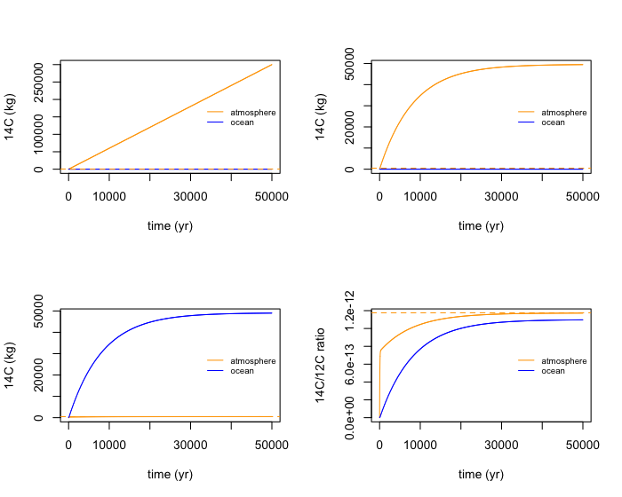

```r
layout(matrix(1:4, ncol=2, byrow=TRUE))
C14.cycle(as.ratio=FALSE, exchange=0, halflife=Inf) # top-left panel
C14.cycle(as.ratio=FALSE, exchange=0) # top-right
C14.cycle(as.ratio=FALSE) # bottom-left
C14.cycle() # bottom-right
```

Given a starting concentration $A_0$ of some organic material that we want to find the age of, the remaining amount of radiocarbon at time $t$ can be found as $A_t = A_0 e^{-\lambda t}$:

```r
howmuchC14(0)
```

```
## 1 mg carbon contains 5.02e+19 C atoms
```

```
## 14C atoms remaining at 0 cal BP (F=0.976): 5.76e+07
```

```
## 19.1 14C atoms in the sample will decay each day
```

```
## For a 12C current of 25 micro-ampere (1.56e+14 12C/second) at the AMS detector,
##   179.03 14C particles would be counted per second (10741.8 per minute)
```

```r
howmuchC14(55e3)
```

```
## 1 mg carbon contains 5.02e+19 C atoms
```

```
## 14C atoms remaining at 55000 cal BP (F=0.002): 1.15e+05
```

```
## 0.0382 14C atoms in the sample will decay each day
```

```
## For a 12C current of 25 micro-ampere (1.56e+14 12C/second) at the AMS detector,
##   0.359 14C particles would be counted per second (21.54 per minute)
```

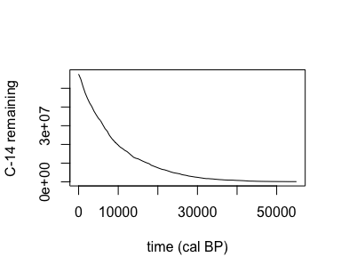

```r
x <- seq(0, 55e3, length=100) # a sequence of ages
y <- sapply(x, function(x) howmuchC14(x, talk=FALSE)[1])
plot(x, y, type="l", xlab="time (cal BP)", ylab="C-14 remaining")
```

Younger samples will have more C-14 atoms left than older ones, and thus will get higher counts-per-second at the AMS’s C-14 detector. Want to hear a ‘sonification’ of the counts-per-second of C-14 atoms? The frequency of the tone relates to the counts per second, and the clicks represent the particles crashing into the detector. A visualisation of the counts as well as how they translate into a C-14 age is also provided. (This requires the ‘audio’ R package to be installed; if it isn’t, a notification will be displayed with installation instructions.)

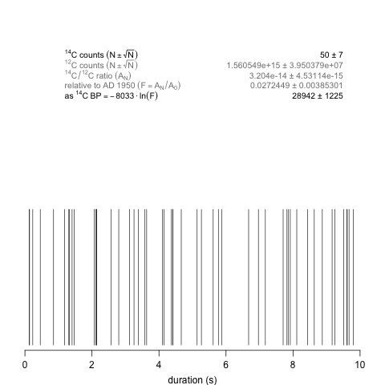

```r
radio(30000)
```

The radiocarbon dating of material of a certain calendar age (e.g., 9000 cal BP) can be simulated quickly and cheaply as:

```r
sim.date(9000, 10) # 10 dates
```

```
##     age er
## 1  8084 44
## 2  7998 44
## 3  8073 44
## 4  8036 44
## 5  8073 44
## 6  8106 44
## 7  8029 44
## 8  8049 44
## 9  8040 44
## 10 8020 44
```

Radiocarbon laboratories correct their measurements for fractionation (to -25 ‰ by default) and for background measurements before they are reported. These calculations can be seen here:

```r
adjust.fractionation(9000, -17) # the sample's d13C was measured at -17
```

```
## [1] 9131.286
```

```r
adjust.background(9000, 50, 48000, 200) # a well-oiled machine, with backgrounds of F=0.00254
```

```
##        C14   C14.er
## 1 9042.384 50.73721
```